# Make Figures

### Decision Curve Analysis

Absolute Net Benefit

Definition: The raw net benefit in terms of true positives and false positives per patient (or per 100 patients). Why report it:

It reflects the real-world clinical impact: how many unnecessary treatments are avoided and how many true cases are detected. Clinicians and decision-makers care about absolute numbers because they relate directly to patient outcomes and resource use.

Example interpretation:

Net benefit = 0.01 at threshold 0.02 means: For every 100 patients, using the model instead of treating all avoids 1 unnecessary treatment without missing any true cases.

✅ Standardized Net Benefit

Definition: Net benefit divided by prevalence (scaled to 0–1). Why report it:

It allows fair comparison across models or populations with different prevalence. It shows how close the model is to the theoretical maximum benefit (perfect prediction). Useful for methodological readers and when prevalence is very low (like your case, 1.9%).

Example interpretation:

Standardized net benefit = 0.8 means the model achieves 80% of the maximum possible utility given the prevalence.

Summary

Absolute NB = practical, clinical relevance. Standardized NB = comparative, methodological insight.

Most published DCA papers include both:

Absolute NB for clinical interpretation. Standardized NB for model performance benchmarking.

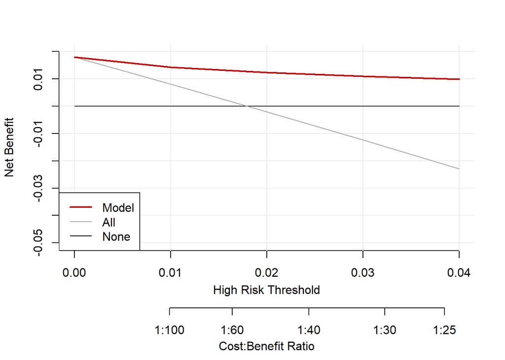

```r
library(rmda)
dc <- decision_curve(lapse ~ prob_raw,
  data = preds_all_raw,
  fitted.risk = TRUE,
  # grid of decision thresholds to use:
  thresholds = seq(0, .04, by = .01),
  # do not calculate confidence intervals:
  confidence.intervals = F
)

plot_decision_curve(
  dc,
  curve.names = c("Model"), # label for your model
  cost.benefit.axis = TRUE,            # optional: add secondary axis
  legend.position = "bottomleft",
  standardize = FALSE                   # optional: standardize net benefit
)
```

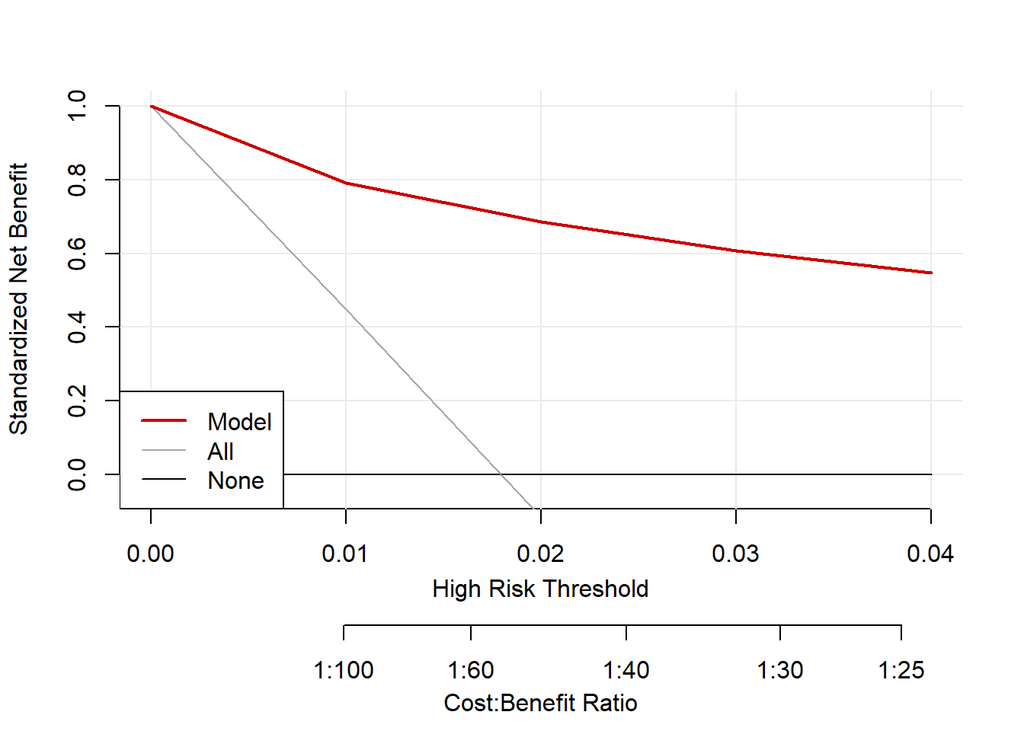

```r
plot_decision_curve(
  dc,
  curve.names = c("Model"), # label for your model
  cost.benefit.axis = TRUE,            # optional: add secondary axis
  legend.position = "bottomleft",
  standardize = TRUE                   # optional: standardize net benefit
)
```

Red line: Your model (prob_raw). Gray line: Treat All. Black line: Treat None (baseline at 0).

Interpretation

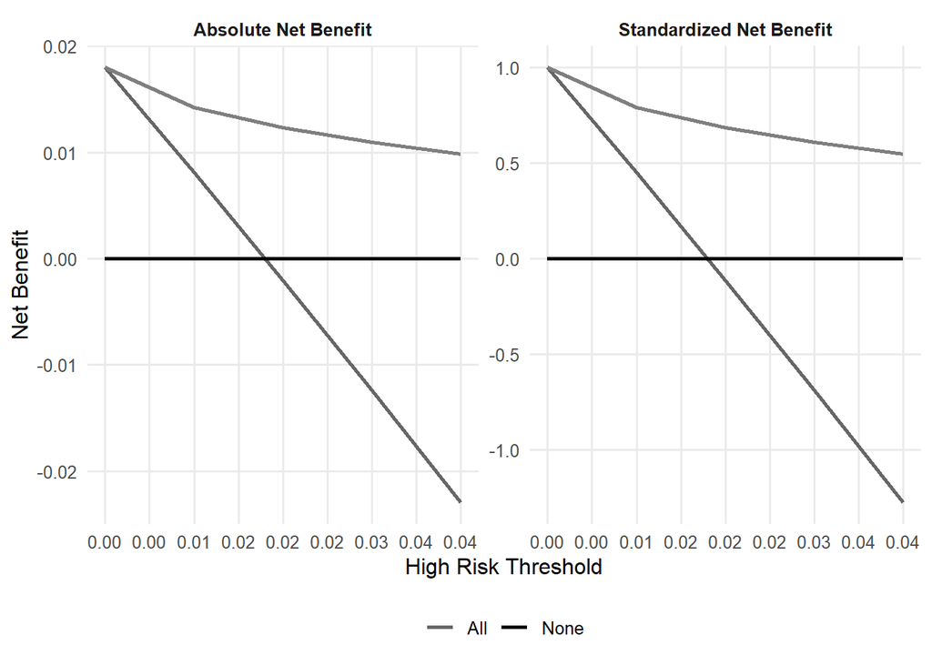

```r
# library(rmda)   # if not already loaded

# 1) compute prevalence (choose ONE of the lines below)
prev <- mean(preds_all_raw$lapse == 1, na.rm = TRUE)

# 2) Extract the net benefit data from the DCA object
#    Most rmda versions store it in `dca_obj$derived.data`.
#    If in your version it's stored differently, run `str(dca_obj)` and update the column names accordingly.
d <- dc$derived.data

# Optional: inspect
# head(d); str(d)

# Expected columns (typical): threshold, net.benefit, model
# If your model name is long, you can optionally relabel it:
d$model <- recode(d$model,
                  "Model (prob_raw)" = "Model",
                  .default = d$model)

# 3) Create standardized net benefit and build a tidy dataset for faceting
plot_df <- bind_rows(
  d %>% transmute(thresholds, nb = NB, model, metric = "Absolute Net Benefit"),
  d %>% transmute(thresholds, nb = NB / prev, model, metric = "Standardized Net Benefit")
)

# 4) Optional: focus the x-range that is clinically relevant
x_max <- 0.04    # set to 0.03 if you want the zoomed clinical view
plot_df <- plot_df %>% filter(thresholds <= x_max)

# 5) Helper to label the secondary x-axis (Cost:Benefit ratio)
ratio_lab <- function(x) {
  r <- x / (1 - x)             # cost:benefit ratio = pt / (1 - pt)
  paste0("1:", number(r, accuracy = 1))
}

# 6) Build the side-by-side ggplot
ggplot(plot_df, aes(x = thresholds, y = nb, color = model)) +
  geom_line(linewidth = 1) +
  facet_wrap(~ metric, ncol = 2, scales = "free_y") +
  scale_color_manual(values = c("Model" = "#D62728", "All" = "grey40", "None" = "black")) +
  scale_x_continuous(
    limits = c(0, x_max),
    breaks = pretty(c(0, x_max), n = 6),
    labels = label_number(accuracy = 0.01),
  ) +
  labs(
    x = "High Risk Threshold",
    y = "Net Benefit",
    color = NULL
  ) +
  theme_minimal(base_size = 12) +
  theme(
    legend.position = "bottom",
    strip.text = element_text(face = "bold"),
    panel.grid.minor = element_blank()
  )
```

### Feature Importance

top 30

```r
shap_levels <- shaps |>
  group_by(variable_grp) |>
  summarize(mean_value = mean(abs(value)), .groups = "drop") |>
  arrange(desc(mean_value)) |>
  slice_head(n = 30) |>
  arrange(mean_value) |>
  pull(variable_grp)

n_obs <- max(shaps$id_obs)

shaps_day_max <- shaps |>
  group_by(id_obs) |>
  slice_max(value) |>
  group_by(variable_grp) |>
  summarise(n = n(),
            prop = n/n_obs) |>
  ungroup()


global_panel <- shaps |>
  group_by(variable_grp) |>
  summarize(mean_value = mean(abs(value)), .groups = "drop") |>
  filter(variable_grp %in% shap_levels) |>
  mutate(variable_grp = factor(variable_grp, levels = shap_levels)) |>
  ggplot(mapping = aes(x = variable_grp, y = mean_value)) +
  geom_bar(fill = "#240e31",
           stat = "identity", position = "dodge") +
  labs(y = "Mean(|Shapley Value|)",
       x = NULL,
       fill = NULL) +
  theme_classic() +
  theme(axis.text=element_text(size=9.5),
        legend.key.size = unit(0.25, "cm"),
        panel.border = element_rect(colour = "black", fill = NA, linewidth = 1),
        legend.position = "right") +
  coord_flip()


local_panel <- shaps_day_max |>
  filter(variable_grp %in% shap_levels) |>
  mutate(variable_grp = factor(variable_grp, levels = shap_levels)) |>
  ggplot(mapping = aes(x = variable_grp, y = prop)) +
  geom_bar(fill = "#046B52",
           stat = "identity", position = "dodge") +
  labs(y = "Proportion of days as top feature",
       x = NULL,
       fill = NULL) +
  theme_classic() +
  theme(axis.text=element_text(size=9.5),
        axis.text.y = element_blank(),
        axis.ticks.y = element_blank(),
        legend.key.size = unit(0.25, "cm"),
        panel.border = element_rect(colour = "black", fill = NA, linewidth = 1),
        legend.position = "right") +
  coord_flip()
```

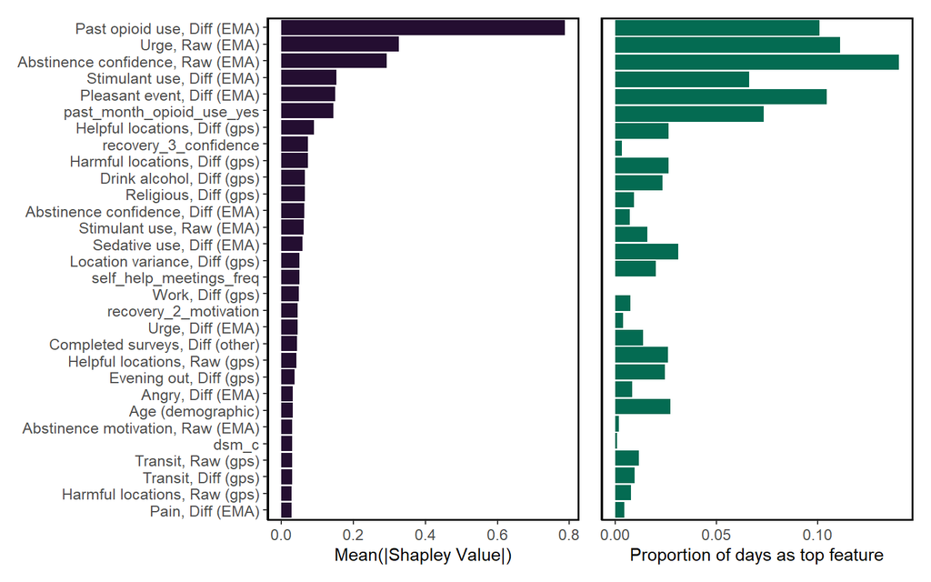

Figure 3

```r
global_panel + local_panel
```

Individual Shapley plots (about 90 categories total)

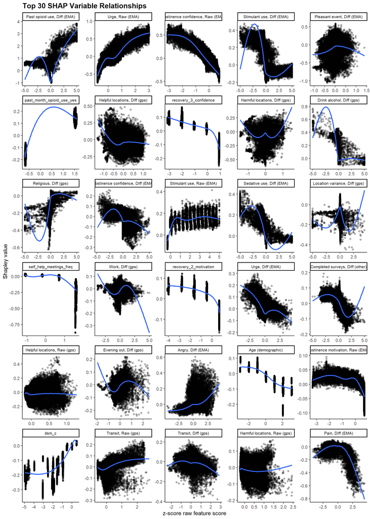

Figure 4: Feature importance partial dependence plots.

```r
shap_levels <- shaps |>
  group_by(variable_grp) |>
  summarize(mean_value = mean(abs(value)), .groups = "drop") |>
  arrange(desc(mean_value)) |>
  slice_head(n = 30) |>
  pull(variable_grp)

shaps|>
  filter(variable_grp %in% shap_levels) |>
  mutate(variable_grp = factor(variable_grp, levels = shap_levels)) |>
  ggplot(aes(x = rfvalue, y = value)) +
  geom_point(alpha = .3) +
  geom_smooth(method = "gam", formula = y ~ s(x, k = 5, bs = "cs"), se = FALSE) +
  facet_wrap(~ variable_grp, scales = "free", ncol = 5) +
  labs(
    title = "Top 30 SHAP Variable Relationships",
    x = "z-score raw feature score",
    y = "Shapley value"
  ) +
  theme_classic() +
  theme(
    strip.text = element_text(size = 8),
    plot.title = element_text(size = 14, face = "bold")
  )
```

Individual Shapley plots by raw and diff

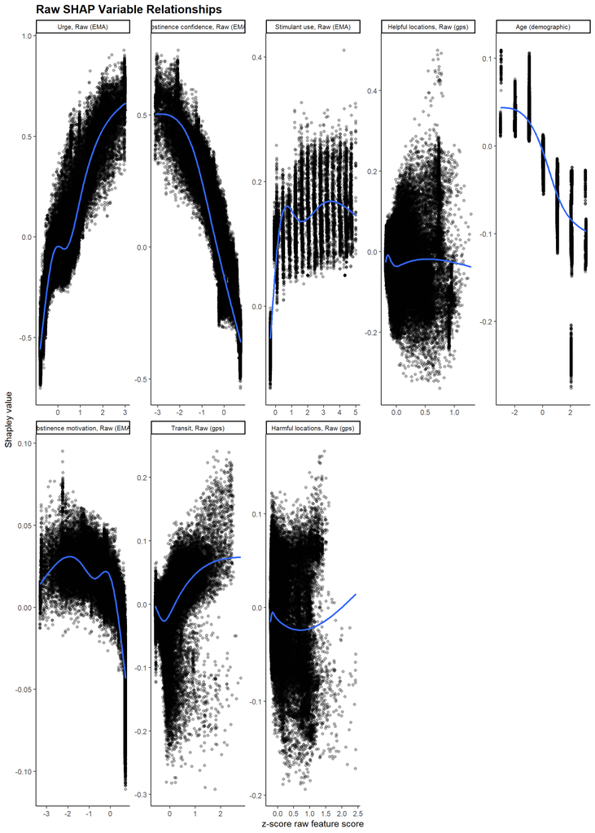

Figure 5: Raw feature importance partial dependence plots.

```r
shap_levels <- shaps |>
  group_by(variable_grp) |>
  summarize(mean_value = mean(abs(value)), .groups = "drop") |>
  arrange(desc(mean_value)) |>
  slice_head(n = 30) |>
  filter(str_detect(variable_grp, "Raw") | str_detect(variable_grp, "demographic")) |>
  pull(variable_grp)

shaps|>
  filter(variable_grp %in% shap_levels) |>
  mutate(variable_grp = factor(variable_grp, levels = shap_levels)) |>
  ggplot(aes(x = rfvalue, y = value)) +
  geom_point(alpha = .3) +
  geom_smooth(method = "gam", formula = y ~ s(x, k = 5, bs = "cs"), se = FALSE) +
  facet_wrap(~ variable_grp, scales = "free", ncol = 5) +
  labs(
    title = "Raw SHAP Variable Relationships",
    x = "z-score raw feature score",
    y = "Shapley value"
  ) +
  theme_classic() +
  theme(
    strip.text = element_text(size = 8),
    plot.title = element_text(size = 14, face = "bold")
  )
```

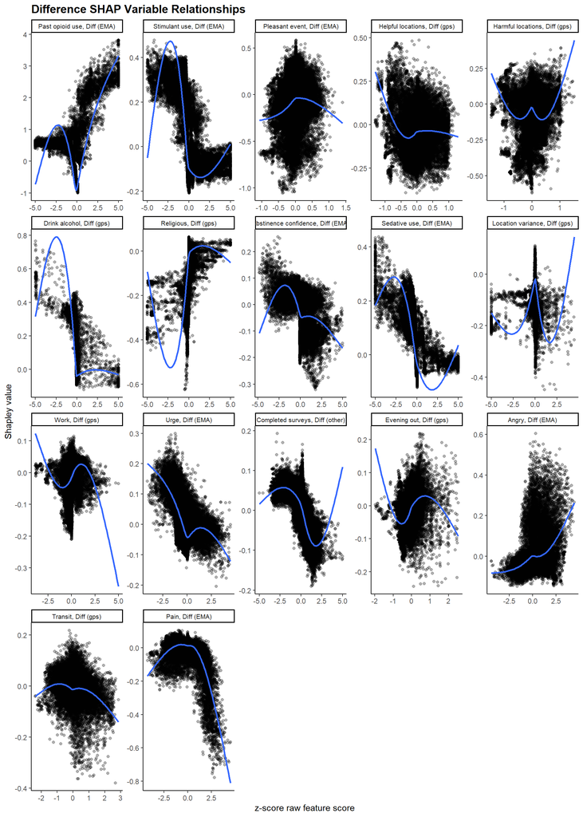

Figure 6: Difference feature importance partial dependence plots.

```r
shap_levels <- shaps |>
  group_by(variable_grp) |>
  summarize(mean_value = mean(abs(value)), .groups = "drop") |>
  arrange(desc(mean_value)) |>
  slice_head(n = 30) |>
  filter(str_detect(variable_grp, "Diff")) |>
  pull(variable_grp)

shaps|>
  filter(variable_grp %in% shap_levels) |>
  mutate(variable_grp = factor(variable_grp, levels = shap_levels)) |>
  ggplot(aes(x = rfvalue, y = value)) +
  geom_point(alpha = .3) +
  geom_smooth(method = "gam", formula = y ~ s(x, k = 5, bs = "cs"), se = FALSE) +
  facet_wrap(~ variable_grp, scales = "free", ncol = 5) +
  labs(
    title = "Difference SHAP Variable Relationships",
    x = "z-score raw feature score",
    y = "Shapley value"
  ) +
  theme_classic() +
  theme(
    strip.text = element_text(size = 8),
    plot.title = element_text(size = 14, face = "bold")
  )
```